# Statusbericht Bachelorprojekt

Berechnungen mit festen Daten

Hendrik Obelöer

13 May 2019

# Veränderungen

| Version | Kommentar | Datum |
| --- | --- | --- |
| 1.0 | erste Version | 29.04.19 |
| 2.0 | - Benutzung von Direktstrahlung anstatt Globalstrahlung - Neuer Ansatz zur Berechnung der Projektionsfläche über kartesische Koordinaten und Reduzierung auf Eindimensionalität - Korrektur der Zeitzone… | 13.05.19 |

# Daten vom deutschen Wetterdienst

Zuerst werden tatsächliche Solardaten über diesen Link vom deutschen Wetterdienst besorgt: ftp://ftp-cdc.dwd.de/pub/CDC/observations_germany/climate/10_minutes/solar/recent/.

Dabei wurde die Wetterstation in Hamburg-Fuhlsbüttel ausgewählt.

| ID | Stationshoehe | geoBreite | geoLaenge |
| --- | --- | --- | --- |
| 01975 | 11 | 53.6332 | 9.9881 |

(Koordinaten sind direkt neben den Startbahnen des Flughafens.)

Wir betrachten nur den Karfreitag 2019, weil dies für die Berechnungen erstmal reicht und dieser Tag ein besonders wolkenloser Tag war. Die gemessenen Strahlungswerte an diesem Tag sehen wie folgt aus:

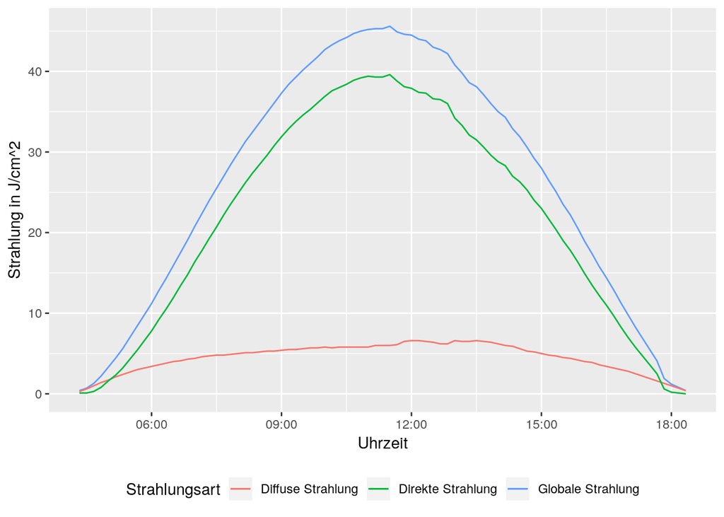

# Sonnenposition

Für den gleichen Ort und Zeitraum werden die Position der Sonne benötigt. Dabei werden Daten dieser Webseite benutzt: https://www.sunearthtools.com/dp/tools/pos_sun.php. Die Daten mit ihren 10-Minuten-Stempeln werden den Daten für die Sonneneinstrahlung zugeordnet.

Die Daten sind als räumlichen Polarkoordinaten gegeben, wobei der Azimuthwinkel von 0-360° ausgedrückt wird und Norden als 0° festgelegt ist. Der Höhenwinkel kann dementsprechend Werte von 0° bis +180° annehmen. Zur weiteren Berechnung werden diese beiden Winkelangaben werden in ein kartesisches NED-Koordinatensystem überführt.

Die Sonnenwinkel sahen am Karfreitag also so aus:

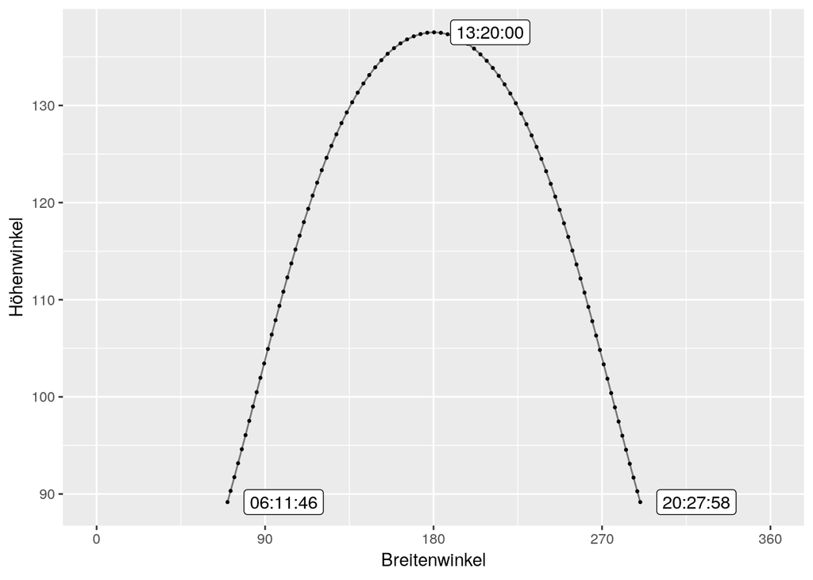

# Berechnung der projezierten Fläche

Zu jedem Zeitpunkt wird die relative “Schattenlänge” bzw. relative Menge an Licht berechnet.

Dabei wird das Skalarprodukt des Normalenvektors der Ausrichtung des Panels und des Einstrahlvektors der Sonne berechnet. Dieser Wert gibt den Anteil an Strahlungsenergie an, den die gekippte Fläche im Vergleich zur perfekt nachgeführten Fläche hat.

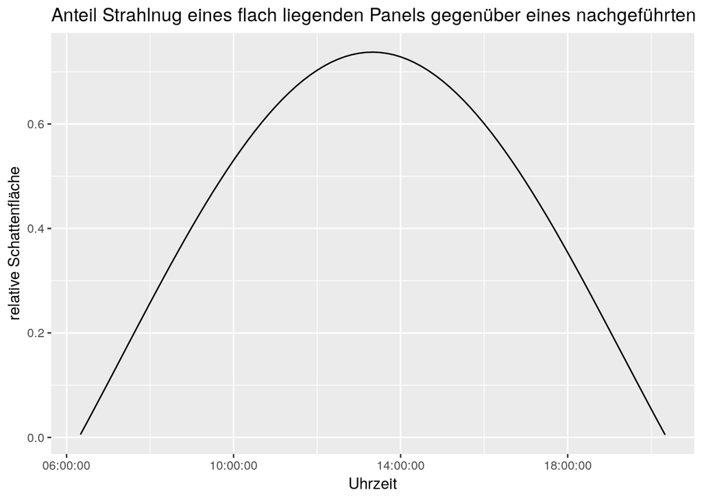

# Vergleich von “Strahlungsertrag”

Die gemessenen Strahlungsdaten beziehen sich stets auf eine flach liegende Fläche. Durch die Multiplikation von Einstrahlungsdaten mit dem Kehrwert des Skalarproduktes der flach liegenden Fläche, kann die aufgefangene Strahlungsenergie der nachgeführten Fläche berechnet werden.

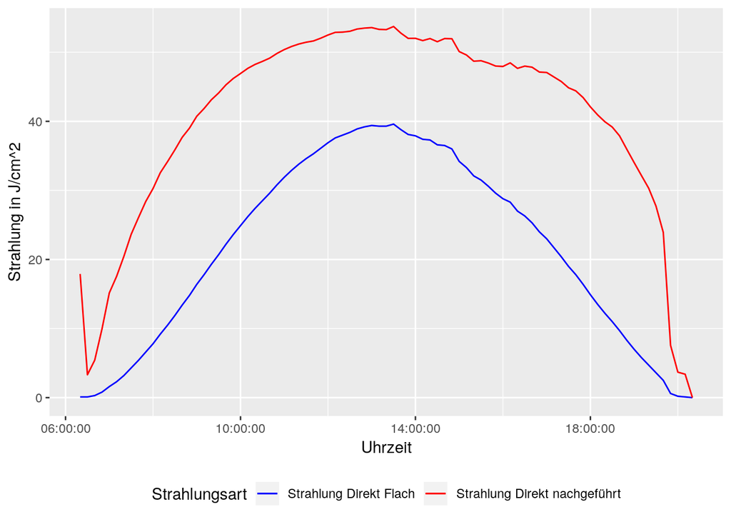

# Daten

hier noch einmal die Daten, um die Ergebnisse nachvollziehen zu können:

## Einstrahlungswerte

| STATIONS_ID | MESS_DATUM | qualitaet | diffuse_strahlung | globale_strahlung | sonnenscheindauer | atmosphaerische_gegenstrahlung | eor | direkte_strahlung |
| --- | --- | --- | --- | --- | --- | --- | --- | --- |
| 1975 | 2017-10-26 00:00:00 | 3 | 0.0 | 0.0 | 0.000 | 17.6 | NA | 0.0 |
| 1975 | 2017-10-26 00:10:00 | 3 | 0.0 | 0.0 | 0.000 | 17.3 | NA | 0.0 |
| 1975 | 2017-10-26 00:20:00 | 3 | 0.0 | 0.0 | 0.000 | 17.6 | NA | 0.0 |
| 1975 | 2017-10-26 00:30:00 | 3 | 0.0 | 0.0 | 0.000 | 17.7 | NA | 0.0 |
| 1975 | 2017-10-26 00:40:00 | 3 | 0.0 | 0.0 | 0.000 | 18.0 | NA | 0.0 |
| 1975 | 2017-10-26 00:50:00 | 3 | 0.0 | 0.0 | 0.000 | 18.0 | NA | 0.0 |
| 1975 | 2017-10-26 01:00:00 | 3 | 0.0 | 0.0 | 0.000 | 18.1 | NA | 0.0 |
| 1975 | 2017-10-26 01:10:00 | 3 | 0.0 | 0.0 | 0.000 | 18.5 | NA | 0.0 |
| 1975 | 2017-10-26 01:20:00 | 3 | 0.0 | 0.0 | 0.000 | 18.6 | NA | 0.0 |
| 1975 | 2017-10-26 01:30:00 | 3 | 0.0 | 0.0 | 0.000 | 18.4 | NA | 0.0 |

[output cut: 9990 more lines]

## Winkel

| uhrzeit | Elevation | Azimuth | datetime | azimuth_rad | elevation_rad | kartesisch |
| --- | --- | --- | --- | --- | --- | --- |
| 06:11:46 | 89.167 | 69.92 | 2019-04-19 06:11:00 | 1.220334 | 1.556258 |  |
| 06:20:00 | 90.320 | 71.57 | 2019-04-19 06:20:00 | 1.249132 | 1.576381 |  |
| 06:30:00 | 91.730 | 73.58 | 2019-04-19 06:30:00 | 1.284213 | 1.600991 |  |
| 06:40:00 | 93.170 | 75.57 | 2019-04-19 06:40:00 | 1.318945 | 1.626123 |  |
| 06:50:00 | 94.610 | 77.56 | 2019-04-19 06:50:00 | 1.353677 | 1.651256 |  |
| 07:00:00 | 96.060 | 79.55 | 2019-04-19 07:00:00 | 1.388409 | 1.676563 |  |
| 07:10:00 | 97.530 | 81.53 | 2019-04-19 07:10:00 | 1.422967 | 1.702220 |  |
| 07:20:00 | 99.000 | 83.51 | 2019-04-19 07:20:00 | 1.457524 | 1.727876 |  |
| 07:30:00 | 100.480 | 85.50 | 2019-04-19 07:30:00 | 1.492257 | 1.753707 |  |
| 07:40:00 | 101.960 | 87.50 | 2019-04-19 07:40:00 | 1.527163 | 1.779538 |  |

[output cut: 77 more lines]